# Exploration 8: Hypothesis Testing

Sreeda Vemuri

10 August, 2020

```r
library("dplyr")   #data wrangling
library("ggplot2") #data visualization
library("magrittr") #to use pipes (%>%)
library("readr")   #to efficiently load a CSV file
```

# Demographics Data

This week we will practice dealing with missing data, and then perform simple hypothesis tests.

Load the spreadsheet file of demographics data with code such as the following.

```r
df <- read_csv("spring2020demographics.csv", col_names = FALSE)
colnames(df) <- readLines("demographics_variable_names.txt")
```

# Example: Units

Colloquial claim: Is the average UCM undergrad student taking more than 15 units?

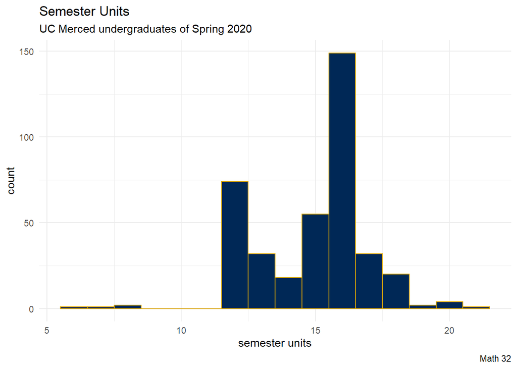

```r
df %>%
  select(unitsThisSemester) %>%
  filter(unitsThisSemester > 0 & unitsThisSemester < 25) %>%
  ggplot(aes(x = unitsThisSemester)) +
  geom_histogram(binwidth = 1, color = "#DAA900", fill = "#002856") +
  labs(title = "Semester Units",
       subtitle = "UC Merced undergraduates of Spring 2020",
       caption = "Math 32",
       x = "semester units",
       y = "count") +
  theme_minimal()
```

$$\huge \begin{array}{c} H_{0}: \mu = 15 \\ H_{a}: \mu > 15 \end{array}$$

```r
t.test(df$unitsThisSemester, mu = 15, alternative = "greater")
```

```
##
##  One Sample t-test
##
## data:  df$unitsThisSemester
## t = 0.98578, df = 392, p-value = 0.1624
## alternative hypothesis: true mean is greater than 15
## 95 percent confidence interval:
##  13.33836      Inf
## sample estimates:
## mean of x
##  17.47074
```

- Inference: Since the p-value of the `t.test` is greater than 0.05, we *fail to reject* the claim of a population average of 15 semester units at the $\alpha = 0.05$ significance level.
- Aside: the colors for the histogram are our [UC Merced color brand standards](https://marketing.ucmerced.edu/resources/brand-guidelines/colors).

# One-Sided Hypothesis Testing

Here we will roughly answer the question: “Is the campus DC ‘appetizing’?”.

Recall that the question in the survey was: “**On a scale from 0 to 100-with 0 = "avoid" and 100 = "appetizing"-what do you think of the campus dining commons ("DC")?**” At first glance, it appears that our hypothesis could be at the maximum value of 100.

Try out the following code to get a sense of how many students answered the survey question as intended (that is, how many observations are NOT missing for this variable) and a sense of the distribution of responses:

```r
sum(!is.na(df$diningCommons))
```

```
## [1] 383
```

```r
summary(df$diningCommons)
```

```
##    Min. 1st Qu.  Median    Mean 3rd Qu.    Max.    NA's
##    0.00   10.00   40.00   37.22   60.00  100.00      15
```

Visualize the `diningCommons` data with a **histogram**. Label the plot with something like “Appetizing DC?” and label the x-axis with “0 = avoid, 100 = appetizing”.

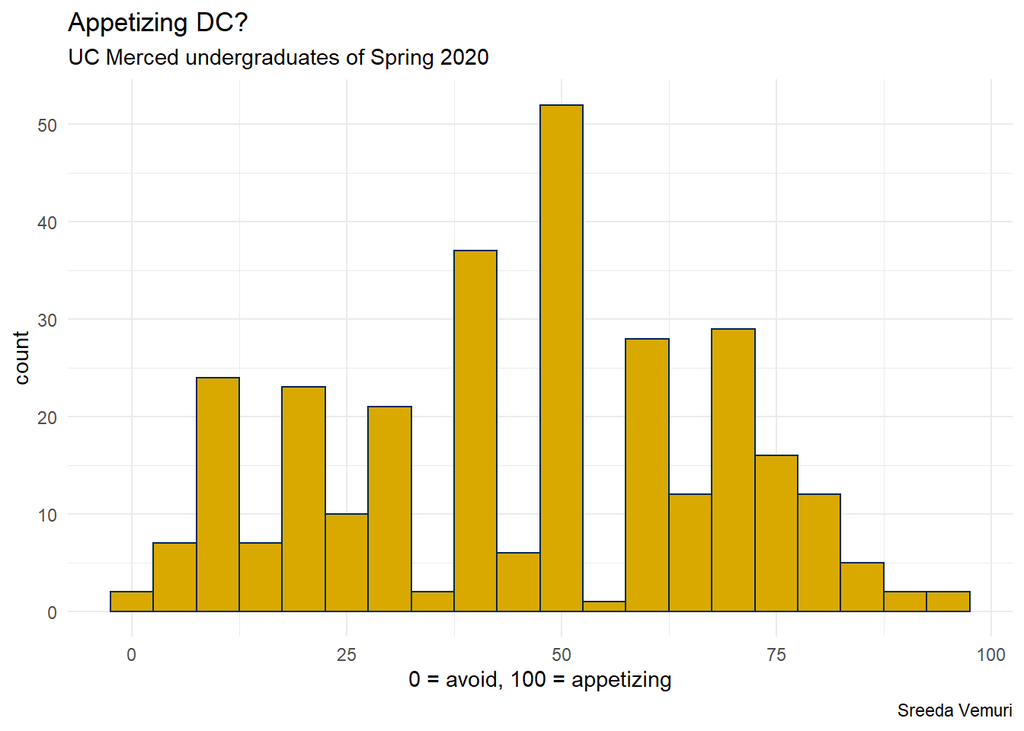

```r
df %>%
  select(diningCommons) %>%
  filter(diningCommons > 0 & diningCommons < 100) %>%
  ggplot(aes(x = diningCommons)) +
  geom_histogram(binwidth = 5, color = "#002856", fill = "#DAA900") +
  labs(title = "Appetizing DC?",
       subtitle = "UC Merced undergraduates of Spring 2020",
       caption = "Sreeda Vemuri",
       x = "0 = avoid, 100 = appetizing",
       y = "count") +
  theme_minimal()
```

# Two-Sided Hypothesis Testing

Here we will roughly answer the question: “Are UC Merced students biased politically?”

Recall that the question in the survey was: “On a scale of 0 to 100—with 0 = Democrat and 100 = Republican—where are your political leanings?” At first glance, it appears that our hypothesis should be in the middle at a value of 50.

Try out the following code to get a sense of what proportion of students answered the survey question and the distribution of responses:

```r
summary(df$politics)
```

```
##    Min. 1st Qu.  Median    Mean 3rd Qu.    Max.    NA's
##     0.0    20.0    40.0    36.5    50.0   300.0      18
```

```r
sum(!is.na(df$politics))/nrow(df) #count of the NOT missing data divided by the number of observations
```

```
## [1] 0.9547739
```

Visualize the `politics` data with a `boxplot`. Label the plot with something like “UC Merced Political Climate” and label the $y$-axis with “0 = Democrat, 100 = Republican”.

## Test the Claim!

Your task is to perform a two-sided hypothesis test using the `t.test` function in `R`:
$$\begin{array}{c} H_{0}: \mu = 50 \\ H_{a}: \mu \neq 50 \end{array}$$
Pay attention in particular to the p-value. How would you interpret that p-value?

```r
t.test(df$politics, mu = 50, alternative = "two.sided")
```

```
##
##  One Sample t-test
##
## data:  df$politics
## t = -9.3915, df = 379, p-value < 2.2e-16
## alternative hypothesis: true mean is not equal to 50
## 95 percent confidence interval:
##  33.67359 39.32641
## sample estimates:
## mean of x
##      36.5
```

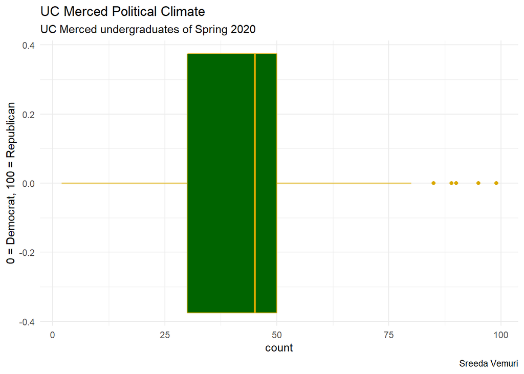

```r
df %>%
  select(politics) %>%
  filter(politics > 0 & politics < 100) %>%
  ggplot(aes(x = politics)) +
  geom_boxplot(color = "#DAA900", fill = "darkgreen") +

  labs(title = "UC Merced Political Climate",
       subtitle = "UC Merced undergraduates of Spring 2020",
       caption = "Sreeda Vemuri",
       x = "count",
       y = "0 = Democrat, 100 = Republican") +
  theme_minimal()
```

# Follow-Up Questions

Collaborate with your classmates and answer the questions below. (Hint: you can *explore* the t-tests above.)

1. Inference from a two-sided hypothesis test may be different that inference from a one-sided hypothesis test (at the same significance level).

```
a. TRUE <--
b. FALSE
```

2. The critical region for a two-sided hypothesis test is twice as large as the critical region for a one-sided hypothesis test.

```
a. TRUE
b. FALSE <--
```

3. If we reject a claim for a two-sided hypothesis test, then we reject the same claim for a one-sided hypothesis test (at the same significance level).

```
a. TRUE
b. FALSE <--
```

Finally, `knit` your work as either an HTML or PDF document, and upload that document back into the CatCourses assignment.